# assignment3

```python
%matplotlib inline
import math
import matplotlib.pyplot as plt
from matplotlib import animation, rc
import numpy as np
import pandas as pd
import seaborn as sns
from numpy import linalg
from scipy import stats
from IPython.display import HTML, display

plt.rcdefaults()
```

## A. Data Preparation

- Dataset : https://github.com/MWiechmann/enron_spam_data Enron Spam Dataset has a total of 33,716 e-mails total with 17,171 spam and 16,545 non-spam ("ham") e-mail messages. It has 5 columns available, 'Message ID', 'Subject','Message','Spam/Ham' and 'Date'.
- Few of the examples in the dataset have NaN values in the subject and message field. This is countered by dropping the examples where message and subject both are NaN.
- Subject and Message are combined to create the email text which helps to add more features for the model.
- This dataset has equal representation across both the classes, which makes it a suitable option for classification task with the objective to classify an new email as spam or ham based on the message.

```python
#https://github.com/MWiechmann/enron_spam_data
emails = pd.read_csv("../data/enron_spam_data.csv", encoding="iso8859-1")
#Load all columns in the dataset
emails[['Message ID','Subject','Message','Spam/Ham','Date']].head()
```

|  | Message ID | Subject | Message | Spam/Ham | Date |
| --- | --- | --- | --- | --- | --- |
| 0 | 0 | christmas tree farm pictures | NaN | ham | 1999-12-10 |
| 1 | 1 | vastar resources , inc . | gary , production from the high island larger ... | ham | 1999-12-13 |
| 2 | 2 | calpine daily gas nomination | - calpine daily gas nomination 1 . doc | ham | 1999-12-14 |
| 3 | 3 | re : issue | fyi - see note below - already done .\nstella\... | ham | 1999-12-14 |
| 4 | 4 | meter 7268 nov allocation | fyi .\n- - - - - - - - - - - - - - - - - - - -... | ham | 1999-12-14 |

```python
# Check for missing values
missing_values = emails.isnull().sum()
print("\nMissing values in each column:")
print(missing_values)

# Drop rows where Message and Subject both are missing
emails = emails.dropna(subset=['Message', 'Subject'], how='all')

print(f"\nDataset size after dropping missing rows: {len(emails)}")
class_counts = emails['Spam/Ham'].value_counts()
total_instances = len(emails)
class_probabilities = class_counts / total_instances
```

```
Missing values in each column:
Message ID      0
Subject       289
Message       371
Spam/Ham        0
Date            0
dtype: int64

Dataset size after dropping missing rows: 33665
```

# B. Probabilities and Zipf

## B.1 Class Distributions and Probabilities

```python
class_table = pd.DataFrame({
    'Class': class_counts.index,
    'Instances': class_counts.values,
    'Probability': class_probabilities.values
})
print(class_table)
```

```
  Class  Instances  Probability
0  spam      17120      0.50854
1   ham      16545      0.49146
```

## B.2 Term Probabilities and Zipf's Law

### B.2.1 Rank, Frequency, and Probability

```python
# B.2.1. Rank terms by frequency and show the top five with probabilities
from sklearn.feature_extraction.text import CountVectorizer

emails['text'] = emails['Subject'].fillna('') + ' ' + emails['Message'].fillna('')
vectorizer = CountVectorizer(stop_words='english')
X = vectorizer.fit_transform(emails['text'])

total_term_count = X.sum()  # total number of term occurrences across all documents
term_frequencies = np.asarray(X.sum(axis=0)).flatten()
terms = vectorizer.get_feature_names_out()

term_freq_df = pd.DataFrame({
    'Term': terms,
    'Rank': 0,  # filled below
    'Frequency': term_frequencies,
    'Probability': term_frequencies / total_term_count  # p(t) = f(t) / sum of all term counts
})

term_freq_df = term_freq_df.sort_values(by='Frequency', ascending=False).reset_index(drop=True)
term_freq_df['Rank'] = term_freq_df.index + 1

top5 = term_freq_df[['Term', 'Rank', 'Frequency', 'Probability']].head(5)
print(top5.to_string(index=True))
```

```
      Term  Rank  Frequency  Probability
0    enron     1      60909     0.012840
1      ect     2      35346     0.007451
2      com     3      24184     0.005098
3  company     4      22959     0.004840
4      hou     5      17264     0.003639
```

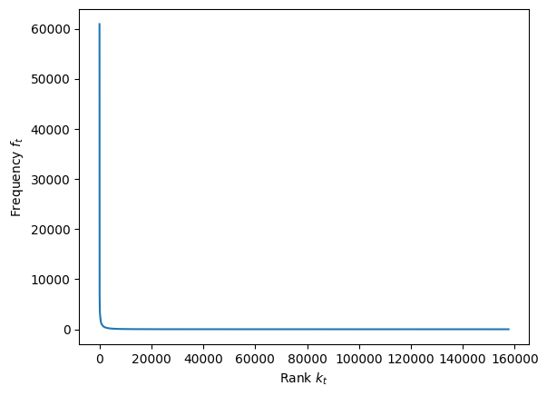

```python
plt.plot(term_freq_df['Rank'], term_freq_df['Frequency'])
plt.xlabel('Rank $k_t$')
plt.ylabel('Frequency $f_t$')
plt.show()
```

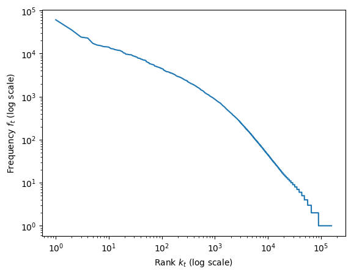

```python
# transfor to log cordinates
plt.loglog(term_freq_df['Rank'], term_freq_df['Frequency'])
plt.xlabel('Rank $k_t$ (log scale)')
plt.ylabel('Frequency $f_t$ (log scale)')
plt.show()
```

### B2.2.2 Probability vs. Rank Plot

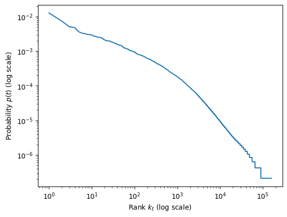

```python
# Compute each terms probability and plot on log-log scale
term_freq_df['Probability'] = term_freq_df['Frequency'] / total_term_count
plt.loglog(term_freq_df['Rank'], term_freq_df['Probability'])
plt.xlabel('Rank $k_t$ (log scale)')
plt.ylabel('Probability $p(t)$ (log scale)')
plt.show()
```

### B2.2.3 Regression Line

The fitted line as seen below from the plot showing the observed data with predicted data.

```
Regression coefficient (Zipf exponent): -1.4467
Intercept: 1.6362
Interpretation: p(t) ∝ 1 / k^1.45
```

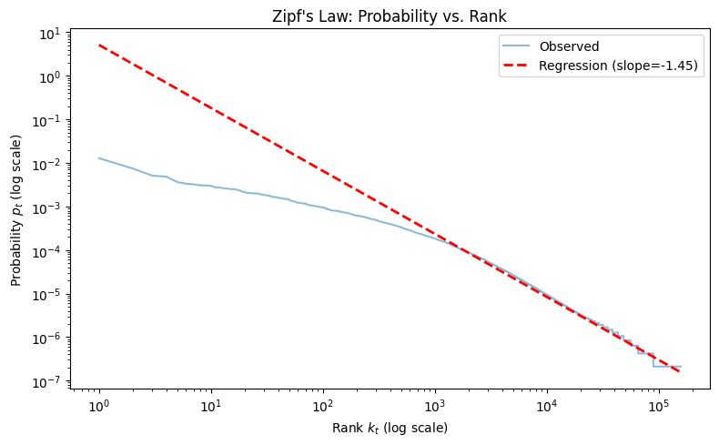

```python
# B.2.3. Linear regression on log(p_t) ~ log(k_t) to estimate Zipf exponent
from sklearn.linear_model import LinearRegression

# x = log(rank), y = log(probability) — fit directly, no double-log
x = np.log(term_freq_df['Rank'].values).reshape(-1, 1)
y = np.log(term_freq_df['Probability'].values)

lm = LinearRegression()
lm.fit(x, y)
y_pred = lm.predict(x)

coef = lm.coef_[0]
print(f"Regression coefficient (Zipf exponent): {coef:.4f}")
print(f"Intercept: {lm.intercept_:.4f}")
print(f"Interpretation: p(t) ∝ 1 / k^{abs(coef):.2f}")

# Plot data and regression line on log-log scale
plt.figure(figsize=(8, 5))
plt.loglog(term_freq_df['Rank'], term_freq_df['Probability'], alpha=0.5, label='Observed')
plt.loglog(term_freq_df['Rank'], np.exp(y_pred), 'r--', linewidth=2, label=f'Regression (slope={coef:.2f})')
plt.xlabel('Rank $k_t$ (log scale)')
plt.ylabel('Probability $p_t$ (log scale)')
plt.title("Zipf's Law: Probability vs. Rank")
plt.legend()
plt.tight_layout()
plt.show()
```

# C. Text Vectorization

## C.1 Training and Test Data

```python
# Split dataset into training and test sets
from sklearn.model_selection import train_test_split
X_train, X_test, y_train, y_test = train_test_split(
    emails['text'], emails['Spam/Ham'], test_size=0.2, random_state=42, stratify=emails['Spam/Ham']
)
print(f"Training set size: {len(X_train)}")
print(f"Test set size: {len(X_test)}")
```

```
Training set size: 26932
Test set size: 6733
```

## C2. Text Vectorization

```python
# Vectorize the training and test data using the same vectorizer
vectorizer = CountVectorizer(stop_words='english')
X_train_vec = vectorizer.fit_transform(X_train)
X_test_vec = vectorizer.transform(X_test)

ham_index = emails['Spam/Ham'] == 'ham'
hams = emails[ham_index]
spams = emails[~ham_index]
X_hams = vectorizer.transform(hams['text'])
X_spams = vectorizer.transform(spams['text'])
print(f"Ham matrix shape: {X_hams.shape}")
```

```
Ham matrix shape: (16545, 142812)
```

## C3. Terms and Conditional Probabilities

- Two words chosen are t1=prize; t2= meeting which are relevant to the class c1=spam; c2=ham respectively.
- The probabilities p(t1/c1), p(t1/c2), p(t2/c1) and p(t2/c2) represent the number of message that were marked to the class (c1/c2) when the target word (t1/t2) was present in the message. They provide the information that how likely is a word to be present in the message when it belongs to a class.
- The probability values are sensible based on the common email patterns. The word prize is more likely to appear in a email which is spam whereas you would expect the word meeting to appear more likely in a non-spam email.
- These values are particularly useful in classification task as they difference between P(word/spam) and P(word/ham) for the terms show a clear indication as to which class email belongs to.

```python
# Use the training vectorizer's vocabulary
terms_train = vectorizer.get_feature_names_out()

t1, t2 = 'prize', 'meeting'

# Guard: confirm both terms exist in training vocabulary
assert t1 in vectorizer.vocabulary_, f"'{t1}' not in training vocabulary"
assert t2 in vectorizer.vocabulary_, f"'{t2}' not in training vocabulary"

i1 = vectorizer.vocabulary_[t1]
i2 = vectorizer.vocabulary_[t2]

print(f"Term '{t1}' -> vocab index {i1}")
print(f"Term '{t2}' -> vocab index {i2}")
```

```
Term 'prize' -> vocab index 102260
Term 'meeting' -> vocab index 83764
```

```python
# Conditional probabilities using training vectorizer (same vocab as models will use)
ham_mask  = emails['Spam/Ham'] == 'ham'
X_hams  = vectorizer.transform(emails.loc[ham_mask,  'text'])
X_spams = vectorizer.transform(emails.loc[~ham_mask, 'text'])

total_ham_terms  = X_hams.sum()
total_spam_terms = X_spams.sum()

term_ham_count1  = X_hams[:,  i1].sum()
term_spam_count1 = X_spams[:, i1].sum()
term_ham_count2  = X_hams[:,  i2].sum()
term_spam_count2 = X_spams[:, i2].sum()

p_t1_ham  = term_ham_count1  / total_ham_terms
p_t1_spam = term_spam_count1 / total_spam_terms
p_t2_ham  = term_ham_count2  / total_ham_terms
p_t2_spam = term_spam_count2 / total_spam_terms

print(f"P('{t1}' | ham)  = {p_t1_ham:.6f}")
print(f"P('{t1}' | spam) = {p_t1_spam:.6f}")
print(f"P('{t2}' | ham)  = {p_t2_ham:.6f}")
print(f"P('{t2}' | spam) = {p_t2_spam:.6f}")
```

```
P('prize' | ham)  = 0.000022
P('prize' | spam) = 0.000474
P('meeting' | ham)  = 0.001779
P('meeting' | spam) = 0.000081
```

# D. Classification

## D.1 Probabilistic Naive Bayes Model (Bernoulli)

- Depending on the task and objective of the model any of the 4 values from the evaluated confusion matrix can vary drastically,
  - Minimize False Negatives -> In critical scenarios where decisions may have life-threatening consequences, it may be acceptable to have false alarms if it ensures the model does not miss an actual positive case for eg. screening a medical device for equipment failure.
  - Minimize False Positives -> In some scenarios it can be more expensive to have false alarms. For eg in case of spam detection a false positive could mean the end user may miss an important email.
  - Minimize both FP and FN (Maximize F1 Score) -> Tasks with balanced datasets where both types of errors can have similar consequences. It might be preferable to maximize the F1 score of the model which is a measure of how good the models precision and recall is which directly affects to minimize False positives and False Negatives.

Hence to compare the performance of the model here with different values of alpha I have used F1 score in addition to accuracy and kappa.

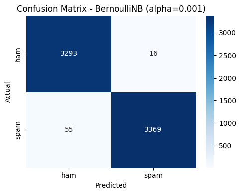

```
alpha=0.001  Accuracy=0.9895  Kappa=0.9789  F1(spam)=0.9896
```

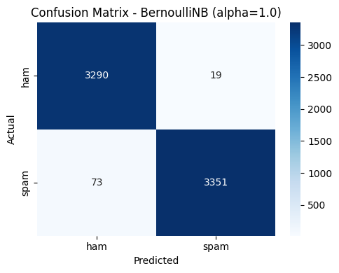

```
alpha=1.0  Accuracy=0.9863  Kappa=0.9727  F1(spam)=0.9865
```

|  | Model | Accuracy | Cohen's Kappa | F1 Score (spam) |
| --- | --- | --- | --- | --- |
| 0 | Naive Bayes alpha=0.001 | 0.989455 | 0.978908 | 0.989573 |
| 1 | Naive Bayes alpha=1.0 | 0.986336 | 0.972671 | 0.986459 |

```python
# D.1. Bernoulli Naive Bayes classification
from sklearn.naive_bayes import BernoulliNB
from sklearn.metrics import accuracy_score, cohen_kappa_score, f1_score, confusion_matrix

results = []

for alpha in [0.001, 1.0]:
    bnb = BernoulliNB(alpha=alpha, binarize=0.0)
    bnb.fit(X_train_vec, y_train)
    y_pred = bnb.predict(X_test_vec)

    accuracy = accuracy_score(y_test, y_pred)
    kappa = cohen_kappa_score(y_test, y_pred)
    f1_spam = f1_score(y_test, y_pred, pos_label='spam')
    results.append({'Model': f'Naive Bayes alpha={alpha}', 'Accuracy': accuracy, "Cohen's Kappa": kappa, 'F1 Score (spam)': f1_spam})

    cm = confusion_matrix(y_test, y_pred, labels=bnb.classes_)
    fig, ax = plt.subplots(figsize=(5, 4))
    sns.heatmap(cm, annot=True, fmt='d', cmap='Blues',
                xticklabels=bnb.classes_, yticklabels=bnb.classes_, ax=ax)
    ax.set_xlabel('Predicted')
    ax.set_ylabel('Actual')
    ax.set_title(f'Confusion Matrix - BernoulliNB (alpha={alpha})')
    plt.tight_layout()
    plt.show()

    print(f"alpha={alpha}  Accuracy={accuracy:.4f}  Kappa={kappa:.4f}  F1(spam)={f1_spam:.4f}\n")

# Summary table
results_df = pd.DataFrame(results)
display(results_df)
```

# D. Linear Model

## D.2.1 Linearity

Based on the graph below showing the term count for the selected words.

- As we can see from the plotted graph the two classes are not perfectly separable from each other as there seems to be overlap in the term counts for the words prize and meeting.
- The two classes do not look to be linearly separable as their is no single line that can separate ham vs spam without any overlap.
- It is possible in a higher dimensional space with more term features may be linearly separable, as additional terms may help to linearly separate the classes.

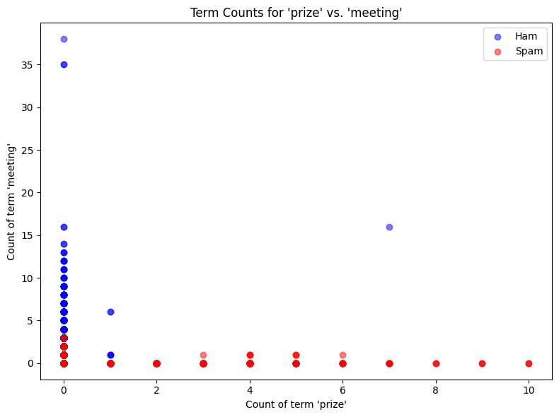

```python
plt.figure(figsize=(8, 6))
plt.scatter(X_hams[:, i1].toarray(), X_hams[:, i2].toarray(), color='blue', alpha=0.5, label='Ham')
plt.scatter(X_spams[:, i1].toarray(), X_spams[:, i2].toarray(), color='red', alpha=0.5, label='Spam')
plt.xlabel(f"Count of term '{t1}'")
plt.ylabel(f"Count of term '{t2}'")
plt.title(f"Term Counts for '{t1}' vs. '{t2}'")
plt.legend()
plt.tight_layout()
plt.show()
```

### D2.2 Linear Classification (Perceptron)

- The parameter used to compare model performance is **max_iter** which control the number of training iterations. As we saw above the data is not perfectly linearly separable hence the model with only 5 iterations is already able to find a good solution but with more iterations the model does not converge fully.

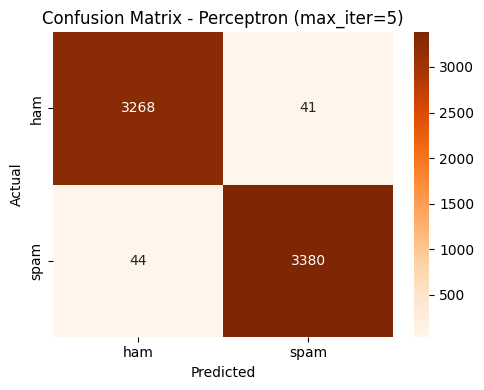

```
max_iter=5  Accuracy=0.9874  Kappa=0.9747  F1(spam)=0.9876
```

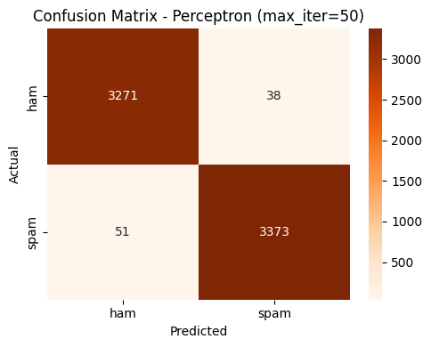

```
max_iter=50  Accuracy=0.9868  Kappa=0.9736  F1(spam)=0.9870
```

|  | Model | Accuracy | Cohen's Kappa | F1 Score (spam) |
| --- | --- | --- | --- | --- |
| 0 | Perceptron max_iter=5 | 0.9874 | 0.9747 | 0.9876 |
| 1 | Perceptron max_iter=50 | 0.9868 | 0.9736 | 0.9870 |

```python
from sklearn.linear_model import Perceptron
from sklearn.metrics import accuracy_score, cohen_kappa_score, f1_score, confusion_matrix

perc_results = []

for max_iter in [5, 50]:
    perc = Perceptron(max_iter=max_iter, random_state=42, tol=None)
    perc.fit(X_train_vec, y_train)
    y_pred_p = perc.predict(X_test_vec)

    acc = accuracy_score(y_test, y_pred_p)
    kap = cohen_kappa_score(y_test, y_pred_p)
    f1s = f1_score(y_test, y_pred_p, pos_label='spam')
    perc_results.append({
        'Model': f'Perceptron max_iter={max_iter}',
        'Accuracy': round(acc, 4),
        "Cohen's Kappa": round(kap, 4),
        'F1 Score (spam)': round(f1s, 4)
    })

    cm = confusion_matrix(y_test, y_pred_p, labels=perc.classes_)
    fig, ax = plt.subplots(figsize=(5, 4))
    sns.heatmap(cm, annot=True, fmt='d', cmap='Oranges',
                xticklabels=perc.classes_, yticklabels=perc.classes_, ax=ax)
    ax.set_xlabel('Predicted')
    ax.set_ylabel('Actual')
    ax.set_title(f'Confusion Matrix - Perceptron (max_iter={max_iter})')
    plt.tight_layout()
    plt.show()
    print(f"max_iter={max_iter}  Accuracy={acc:.4f}  Kappa={kap:.4f}  F1(spam)={f1s:.4f}\n")

display(pd.DataFrame(perc_results))
```

## D.3 Non-linear Classification (Non-linear Multi-layer Perceptron)

- The parameter used for comparison is **hidden_layer_sizes**. The smaller single layer (50,) model outperforms the deeper model (200, 100) suggesting single-layer network captures the key patterns without overfitting on this dataset.

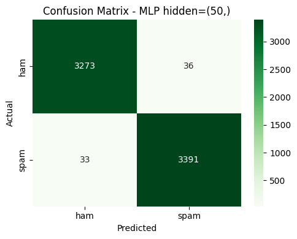

```
hidden=(50,)  Accuracy=0.9898  Kappa=0.9795  F1(spam)=0.9899
```

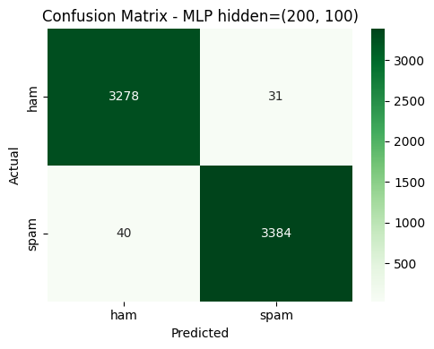

```
hidden=(200, 100)  Accuracy=0.9895  Kappa=0.9789  F1(spam)=0.9896
```

|  | Model | Accuracy | Cohen's Kappa | F1 Score (spam) |
| --- | --- | --- | --- | --- |
| 0 | MLP hidden=(50,) | 0.9898 | 0.9795 | 0.9899 |
| 1 | MLP hidden=(200, 100) | 0.9895 | 0.9789 | 0.9896 |

```python
from sklearn.neural_network import MLPClassifier
from sklearn.metrics import accuracy_score, cohen_kappa_score, f1_score, confusion_matrix

mlp_results = []

for hidden in [(50,), (200, 100)]:
    mlp = MLPClassifier(hidden_layer_sizes=hidden, solver='lbfgs', max_iter=100, random_state=42)
    mlp.fit(X_train_vec, y_train)
    y_pred_m = mlp.predict(X_test_vec)

    acc = accuracy_score(y_test, y_pred_m)
    kap = cohen_kappa_score(y_test, y_pred_m)
    f1s = f1_score(y_test, y_pred_m, pos_label='spam')
    mlp_results.append({
        'Model': f'MLP hidden={hidden}',
        'Accuracy': round(acc, 4),
        "Cohen's Kappa": round(kap, 4),
        'F1 Score (spam)': round(f1s, 4)
    })

    cm = confusion_matrix(y_test, y_pred_m, labels=mlp.classes_)
    fig, ax = plt.subplots(figsize=(5, 4))
    sns.heatmap(cm, annot=True, fmt='d', cmap='Greens',
                xticklabels=mlp.classes_, yticklabels=mlp.classes_, ax=ax)
    ax.set_xlabel('Predicted')
    ax.set_ylabel('Actual')
    ax.set_title(f'Confusion Matrix - MLP hidden={hidden}')
    plt.tight_layout()
    plt.show()
    print(f"hidden={hidden}  Accuracy={acc:.4f}  Kappa={kap:.4f}  F1(spam)={f1s:.4f}\n")

display(pd.DataFrame(mlp_results))
```

# E. Conclusion

| Model | Accuracy | Cohen's Kappa | F1 Score (spam) |
| --- | --- | --- | --- |
| Bernoulli Naive Bayes | 0.989455 | 0.978908 | 0.989573 |
| Perceptron | 0.9874 | 0.9747 | 0.9876 |
| Non-linear Multi-layer Perceptron | 0.9898 | 0.9795 | 0.9899 |

The above table shows the scores of the best model from each category. **Non-linear Multi-layer Perceptron** model achieves the best score overall in all the three metrics tracked. MLP model achieves an accuracy of 0.9898, which is slightly better than naive bayes model. The MLP model may benefit from additional context of subject + email in the training samples.

The **Perceptron** model underperforms because it is sensitive to order of training samples and the non-convergence is caused by the overlap between two classes.

### Future Work

- Adding more and diverse training examples could help improve all models.
- Applying TF-IDF weighting instead of raw counts could help reduce the dominance of specific terms towards a particular class.
- Additional work on the data could include adding more classes instead of the current binary range of spam/ham. More labels like marketing/promotion, fishing, suspicious, valid etc. can help in distribution of classes and make the classification task easier.